# MD 9 Demo

2022-11-15

```r
library(tidyverse)
library(infer)
library(moderndive)
library(patchwork)
library(here)
library(ggplot2movies)
theme_set(theme_minimal())
```

# Review

What is a seed, anyway? (“Phone book” example.)

# Hypothesis testing

## Promotions example

Sex differences in promotion?

```r
set.seed(1234)

promotions <- promotions |>
  rename(sex = gender)       # more accurate name

promotions |>
  sample_n(size = 6) |>
  head()
```

```
## # A tibble: 6 × 3
##      id decision sex
##   <int> <fct>    <fct>
## 1    28 promoted female
## 2    16 promoted male
## 3    22 promoted female
## 4    37 not      male
## 5    44 not      female
## 6     9 promoted male
```

Visualize.

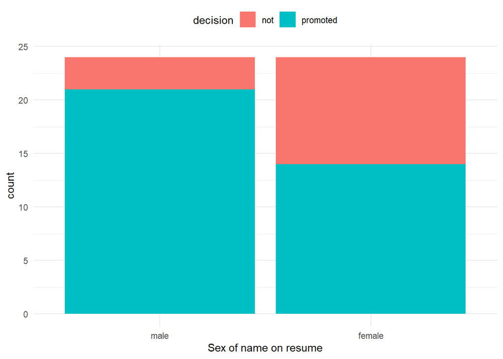

```r
p1 <- ggplot(promotions,
            aes(x = sex,
                fill = decision)) +
  geom_bar() +
  labs(x = "Sex of name on resume") +
  theme(legend.position = "top")

p1
```

`tally()` as shorthand for `summarize(n = n())`

```r
promotions |>
  group_by(sex, decision) |>
  tally()
```

```
## # A tibble: 4 × 3
## # Groups:   sex [2]
##   sex    decision     n
##   <fct>  <fct>    <int>
## 1 male   not          3
## 2 male   promoted    21
## 3 female not         10
## 4 female promoted    14
```

Could this difference occur by chance?

We have 48 people. 24 males; 24 females. What if we were going to promote 35 people by chance?

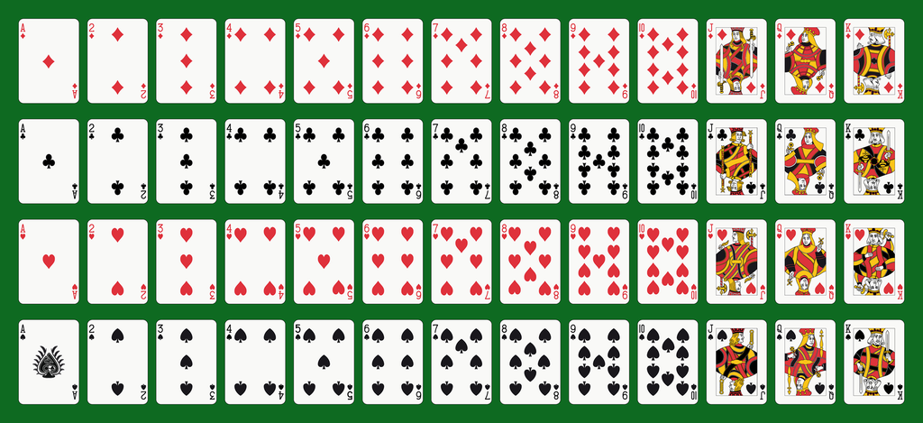

You can think of having a deck of cards, shuffling it, and pulling out 35 people at random.

Let’s convert out outcome into a number (1 = promoted, 0 = not) to make this easier.

```r
promotions <- promotions |>
  mutate(promoted = if_else(decision == "promoted", 1, 0))
```

#### Real data

```r
promotions |>
  group_by(sex) |>
  summarize(mean = mean(promoted))
```

```
## # A tibble: 2 × 2
##   sex     mean
##   <fct>  <dbl>
## 1 male   0.875
## 2 female 0.583
```

#### Shuffled data

```r
# prep the data
promotions_shuffled <- promotions_shuffled |>
  rename(sex = gender) |>
  mutate(promoted = if_else(decision == "promoted", 1, 0))

# summary
promotions_shuffled |>
  group_by(sex) |>
  summarize(mean = mean(promoted))
```

```
## # A tibble: 2 × 2
##   sex     mean
##   <fct>  <dbl>
## 1 male   0.75
## 2 female 0.708
```

Or we can visualize:

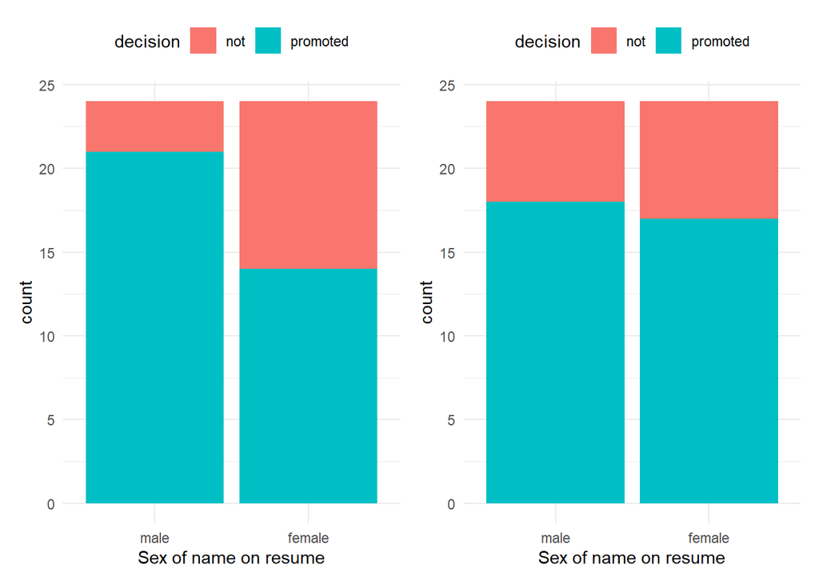

```r
p2 <- ggplot(promotions_shuffled,
             aes(x = sex,
                 fill = decision)) +
  geom_bar() +
  labs(x = "Sex of name on resume") +
  theme(legend.position = "top")

p1 + p2
```

The book shows the results of 16 different shufflings:

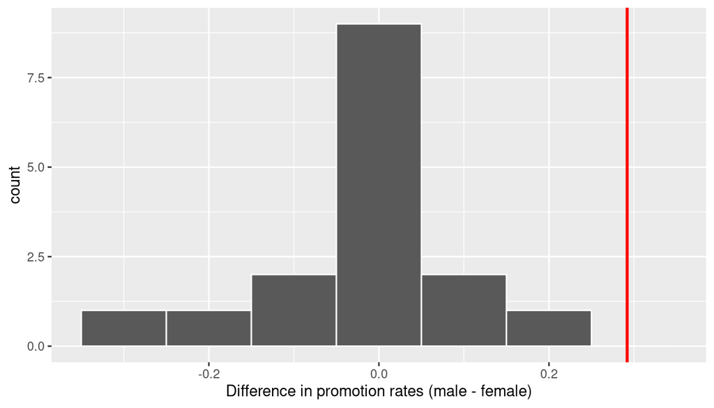

The real world indeed seems to show a sex difference bigger that what we get in an imaginary universe of equality.

## Permutation tests

Permutation is another word for shuffling.

Here are the types of things we might want to check:

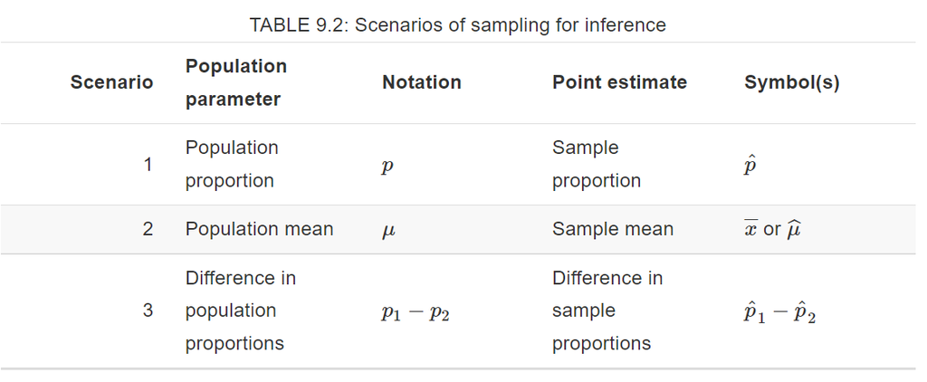

# Understanding hypothesis tests

We are usually comparing a **null hypothesis** with an **alternative hypothesis**. For example

$H_0 : \text{men and women promoted at the same rate}$

$H_A : \text{men and women promoted at different rates}$

The basic gist is that we make up a world that looks like the null and see if real life is so weird that we have to conclude that the null isn’t reasonable.

- Alpha ($\alpha$) level: how weird counts as weird? (This is usually .05 but that’s not a law of the universe)
- p-value: how weird is our actual sample?

The p-value means “if my null model were true, how often would I get a result *this extreme* by chance?”

# Doing this with **infer**

What we’ve been doing:

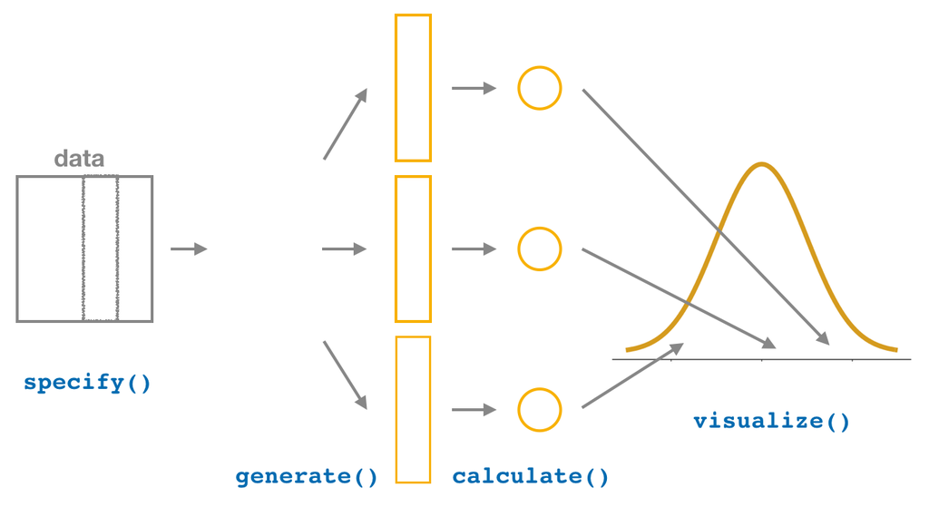

Adding a new step:

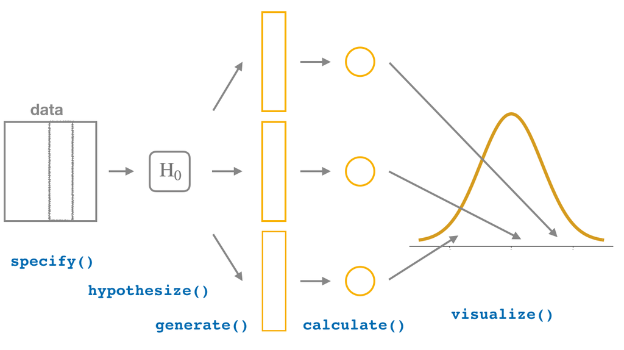

Let’s get the observed difference in proportions.

NOTE: **infer** is weird in that it doesn’t want you to use “proportions” when you have a numeric outcome. Since `promoted` is a 0/1 variable, we use “diff in means”.

Let’s get the observed difference in proportion promoted between males and females.

#### observed

```r
observed_diff <- promotions |>
  specify(promoted ~ sex) |>             # outcome ~ predictor
  calculate(stat = "diff in means",      # which stat we want
            order = c("male", "female")) # male - female

observed_diff
```

```
## Response: promoted (numeric)
## Explanatory: sex (factor)
## # A tibble: 1 × 1
##    stat
##   <dbl>
## 1 0.292
```

#### null distribution

```r
set.seed(12345)

null_distribution <- promotions |>
  specify(formula = promoted ~ sex) |>
  hypothesize(null = "independence") |>  # meaning "no difference"
  generate(reps = 1000,
           type = "permute") |>
  calculate(stat = "diff in means",
            order = c("male", "female"))
null_distribution
```

```
## Response: promoted (numeric)
## Explanatory: sex (factor)
## Null Hypothesis: independence
## # A tibble: 1,000 × 2
##    replicate    stat
##        <int>   <dbl>
##  1         1  0.208
##  2         2  0.125
##  3         3  0.0417
##  4         4 -0.0417
##  5         5 -0.0417
##  6         6  0.125
##  7         7 -0.0417
##  8         8 -0.0417
##  9         9  0.0417
## 10        10  0.0417
## # … with 990 more rows
```

Or we can visualize.

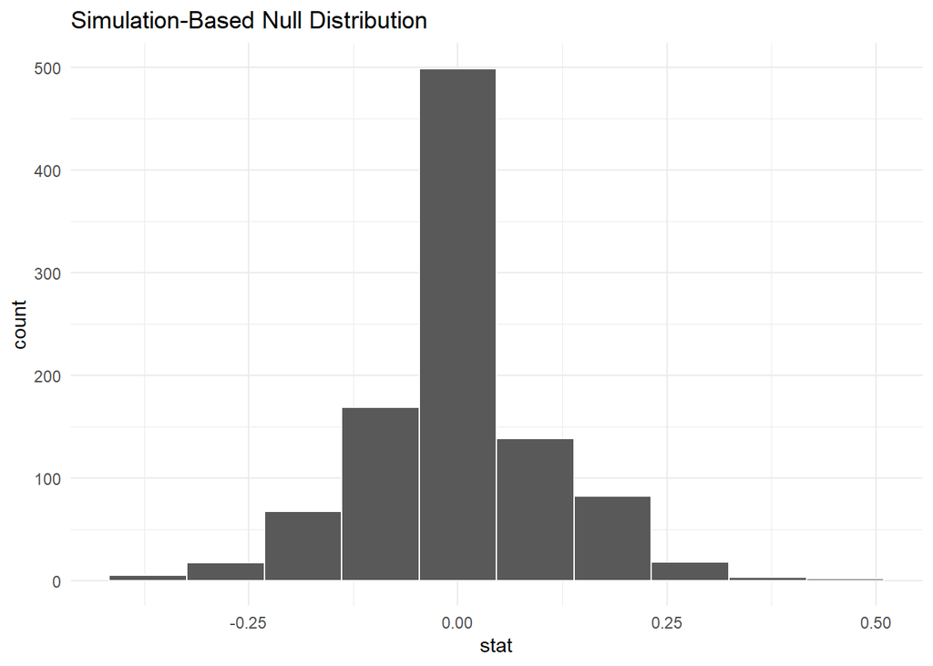

```r
visualize(null_distribution,
          bins = 10)
```

#### getting the p-value

Visually.

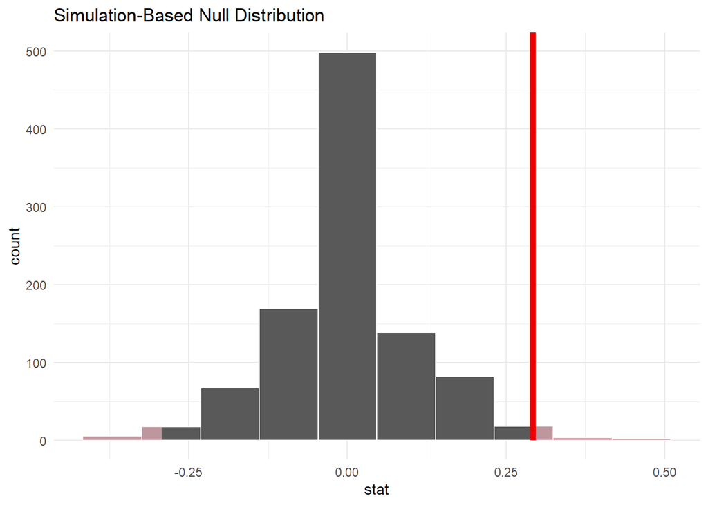

```r
visualize(null_distribution,
          bins = 10) +
  shade_p_value(obs_stat = observed_diff,
                direction = "both")
```

Numerically.

```r
null_distribution |>
  get_p_value(obs_stat = observed_diff,
              direction = "both")
```

```
## # A tibble: 1 × 1
##   p_value
##     <dbl>
## 1   0.046
```

# Comparison to confidence intervals

Confidence intervals and p-values are closely related.

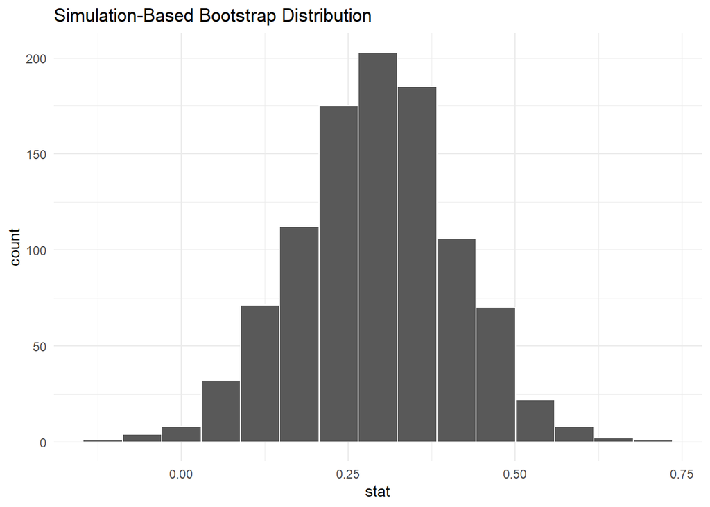

```r
bootstrap_distribution <- promotions |>
  specify(formula = promoted ~ sex) |>
  generate(reps = 1000,
           type = "bootstrap") |>
  calculate(stat = "diff in means",
            order = c("male", "female"))

visualize(bootstrap_distribution)
```

Let’s get the intervals. First numerically:

```r
percentile_ci <- bootstrap_distribution |>
  get_confidence_interval(level = 0.95, type = "percentile")
percentile_ci
```

```
## # A tibble: 1 × 2
##   lower_ci upper_ci
##      <dbl>    <dbl>
## 1   0.0606    0.514
```

Then visually:

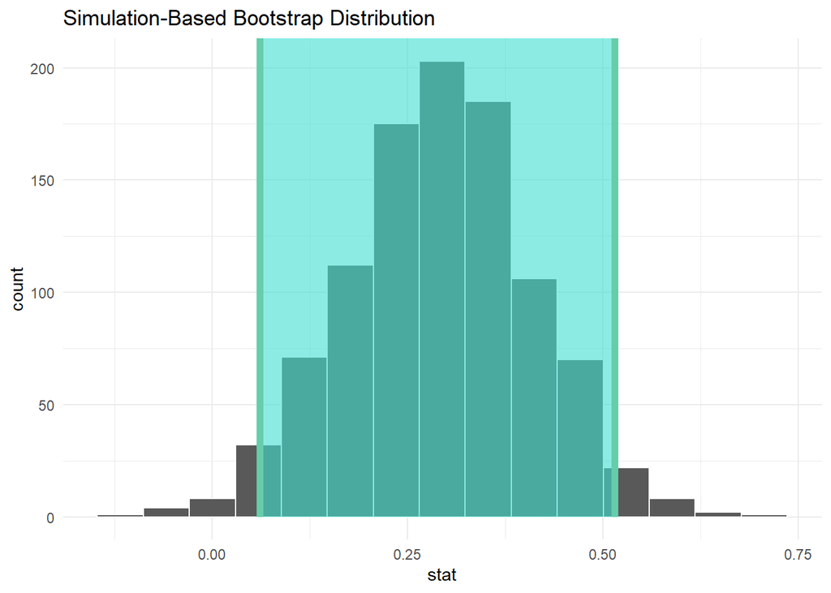

```r
visualize(bootstrap_distribution) +
  shade_confidence_interval(endpoints = percentile_ci)
```

If the 95% confidence interval for the *difference* in male-female promotion rates doesn’t include zero, then that is the same decision rule as rejecting the null hypothesis is the p-value is less than .05.

# Interpretation

- if the p-value is less than $\alpha$ we reject the null hypothesis in favor of the alternative hypothesis
- if the p-value is greater than or equal to $\alpha$, we “fail to reject” the null hypothesis

(Analogy to criminal justice system.)

# Movies case study

This is another example of a research question:

“Are men promoted at different rates than women?”

“Are action moves rated differently than romance movies?”

```r
movies_sample |>
  glimpse()
```

```
## Rows: 68
## Columns: 4
## $ title  <chr> "Underworld", "Love Affair", "Junglee", "Eversmile, New Jersey"…
## $ year   <int> 1985, 1932, 1961, 1989, 1979, 1988, 1991, 1995, 1976, 1979, 198…
## $ rating <dbl> 3.1, 6.3, 6.8, 5.0, 4.0, 4.9, 7.4, 3.5, 7.7, 5.8, 8.9, 3.6, 5.5…
## $ genre  <chr> "Action", "Romance", "Romance", "Romance", "Action", "Romance",…
```

Basic difference:

[figure not shown]

```r
ggplot(data = movies_sample, aes(x = genre, y = rating)) +
  geom_boxplot() +
  labs(y = "IMDb rating")
```

Are these differences big enough for us to assert that there are real differences in the full population of films?

Same basic idea. Here’s the null.

```r
set.seed(12345)

null_distribution <- movies_sample |>
  specify(formula = rating ~ genre) |>
  hypothesise(null = "independence") |>
  generate(reps = 1000,
           type = "permute") |>
  calculate(stat = "diff in means",
            order = c("Action", "Romance"))

head(null_distribution)
```

```
## Response: rating (numeric)
## Explanatory: genre (factor)
## Null Hypothesis: independence
## # A tibble: 6 × 2
##   replicate    stat
##       <int>   <dbl>
## 1         1 -0.0260
## 2         2 -0.823
## 3         3  0.328
## 4         4  0.110
## 5         5  0.428
## 6         6 -0.221
```

Here’s the observed difference.

```r
observed_diff <- movies_sample |>
  specify(formula = rating ~ genre) |>
  calculate(stat = "diff in means",
            order = c("Action", "Romance"))

observed_diff
```

```
## Response: rating (numeric)
## Explanatory: genre (factor)
## # A tibble: 1 × 1
##    stat
##   <dbl>
## 1 -1.05
```

Now check out the observed difference compared to what we’d expect under the “null world”.

Visual:

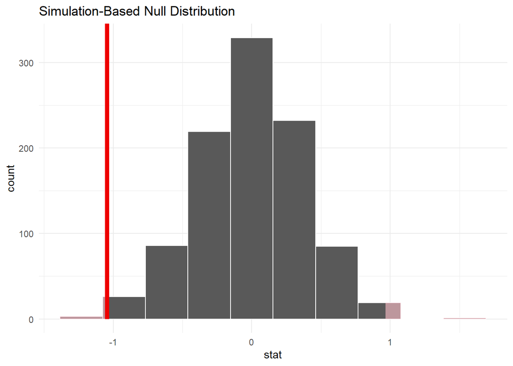

```r
visualize(null_distribution,
          bins = 10) +
  shade_p_value(obs_stat = observed_diff,
                direction = "both")
```

Numeric:

```r
null_distribution |>
  get_p_value(obs_stat = observed_diff,
              direction = "both")
```

```
## # A tibble: 1 × 1
##   p_value
##     <dbl>
## 1   0.008
```